# 04 Tune Model Parameters

[Chapter 4](https://www.tidymodels.org/start/tuning/)

- **Hyperparameters**: cannot be learned directly from the data but have to be estimated on resampled data (tuning). E.g. the number of predictors that are sampled at splits in a tree-based model (`mtry`) or learning rate in a boosted tree model (`learn_rate`).
- For example description description see “03 Model Evaluation with Resampling” but this time a **decision tree model** (not random forest) is used.
- Random Forest performs well with default hyperparameters but other tree-based models can be sensitive to values of hyperparameters because they tend to overfit the data. This example tunes two of serveral possible hyperparameters:
  - Complexity parameter for the tree `cost_complexity`: helps to prune back the tree as it adds a cost to error rates for more complex trees.
  - Maximum `tree_depth`: helps stopping tree from growing after it reaches a certain depth.

```r
library(tidymodels)

# Helper packages
library(rpart.plot)  # for visualizing a decision tree
library(vip)         # for variable importance plots

data(cells, package = "modeldata")
set.seed(123)
cell_split <- initial_split(cells |> select(-case),
                            strata = class)
cell_train <- training(cell_split)
cell_test <- testing(cell_split)
```

## Tuning Hyperparameters

- Create a parsnip model specification that identifies which hyperparameters need to be tuned
- Model specification is used to train many models on resampled data (cannot be trained on a single data set). Data is again split in to “folds” with `vfold_cv()`
- Create a grid of possible hyperparameter values for training (using `dials` with convenience functions for each hyperparameter and `grid_regular()`)

```r
# parsnip model specification for tuning
tune_spec <-
  decision_tree(
    cost_complexity = tune(),
    tree_depth = tune()
  ) |>
  set_engine("rpart") |>
  set_mode("classification")

# grid of possible values to try for tuning
tree_grid <- grid_regular(cost_complexity(),
                          tree_depth(),
                          levels = 5) # 5 example values for each parameter

# create cross-validateion folds for tuning
set.seed(234)
cell_folds <- vfold_cv(cell_train)
```

## Model tuning with a grid

- `tune_grid()` to fit modles at all different values from the grid using `workflow()`
- `show_best()` shows the top 5 candidate models
- `select_best()` to pull the single best set of hyperparameters

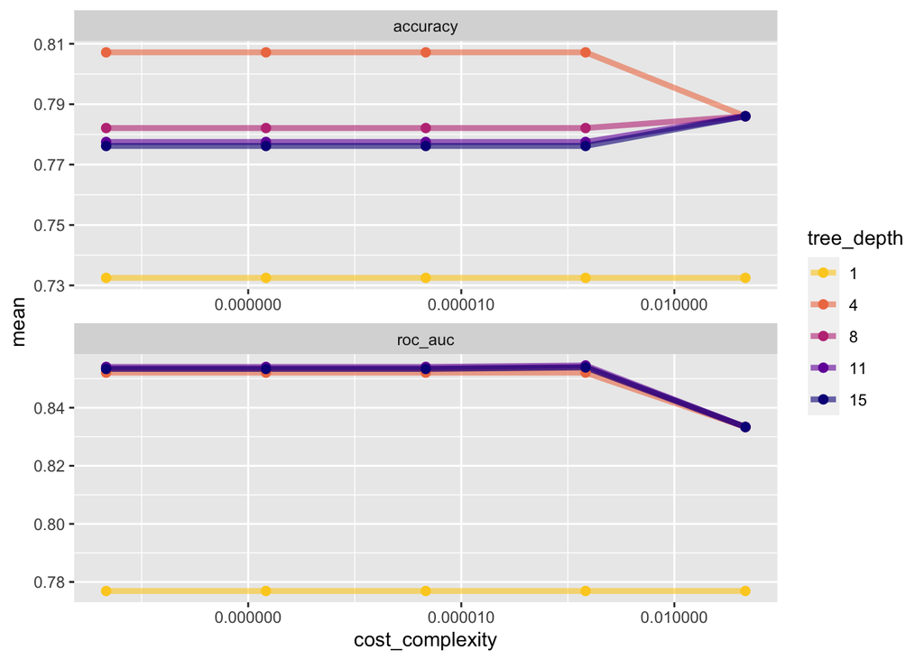

```r
set.seed(345)

tree_wf <-
  workflow() |>
  add_model(tune_spec) |>
  add_formula(class ~ .) # or use add_recipe() if a recipe is needed

tree_res <-
  tree_wf |>
  tune_grid(
    resamples = cell_folds,
    grid = tree_grid
  )

tree_res |>
  collect_metrics() |>
  mutate(tree_depth = factor(tree_depth)) |>
  ggplot(aes(cost_complexity, mean, color = tree_depth)) +
  geom_line(linewidth = 1.5, alpha = 0.6) +
  geom_point(size = 2) +
  facet_wrap(~ .metric, scales = "free", nrow = 2) +
  scale_x_log10(labels = scales::label_number()) +
  scale_color_viridis_d(option = "plasma", begin = .9, end = 0)
```

```r
# tree_res |> show_best("accuracy")
best_tree <- tree_res |>
  select_best("accuracy")

best_tree
```

```
# A tibble: 1 × 3
  cost_complexity tree_depth .config
            <dbl>      <int> <chr>
1    0.0000000001          4 Preprocessor1_Model06
```

## Finalizing the Model

- Update workflow with the selected best values with `finalize_workflow()`
- Fit the final model with `last_fit()` to the training data and use test data to estimate performance
- the finalized, fitted workflow in `final_fit` can be extracted an used for predicting new data

```r
final_wf <-
  tree_wf |>
  finalize_workflow(best_tree)

final_fit <-
  final_wf |>
  last_fit(cell_split)

final_fit |>
  collect_metrics()
```

```
# A tibble: 2 × 4
  .metric  .estimator .estimate .config
  <chr>    <chr>          <dbl> <chr>
1 accuracy binary         0.802 Preprocessor1_Model1
2 roc_auc  binary         0.840 Preprocessor1_Model1
```

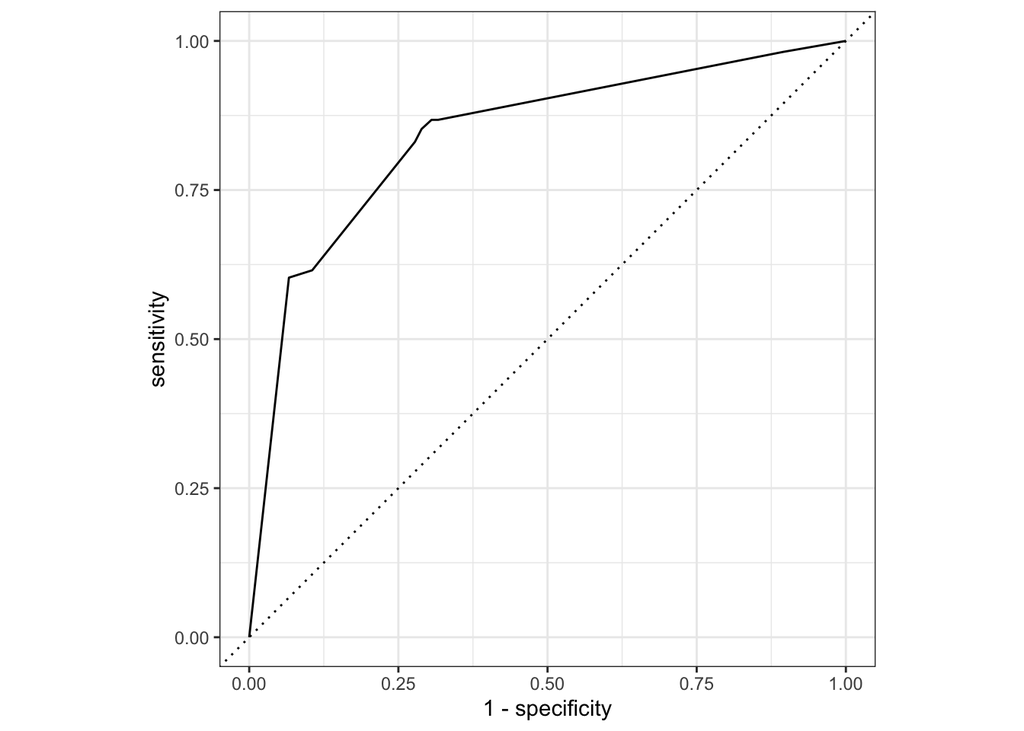

```r
final_fit |>
  collect_predictions() |>
  roc_curve(class, .pred_PS) |>
  autoplot()
```

```r
final_tree <- extract_workflow(final_fit) # final_fit$.workflow[[1]]
final_tree
```

```
══ Workflow [trained] ══════════════════════════════════════════════════════════
Preprocessor: Formula
Model: decision_tree()

── Preprocessor ────────────────────────────────────────────────────────────────
class ~ .

── Model ───────────────────────────────────────────────────────────────────────
n= 1514

node), split, n, loss, yval, (yprob)
      * denotes terminal node

 1) root 1514 539 PS (0.64398943 0.35601057)
   2) total_inten_ch_2< 41732.5 642  33 PS (0.94859813 0.05140187)
     4) shape_p_2_a_ch_1>=1.251801 631  27 PS (0.95721078 0.04278922) *
     5) shape_p_2_a_ch_1< 1.251801 11   5 WS (0.45454545 0.54545455) *
   3) total_inten_ch_2>=41732.5 872 366 WS (0.41972477 0.58027523)
     6) fiber_width_ch_1< 11.37318 406 160 PS (0.60591133 0.39408867)
      12) avg_inten_ch_1< 145.4883 293  85 PS (0.70989761 0.29010239) *
      13) avg_inten_ch_1>=145.4883 113  38 WS (0.33628319 0.66371681)
        26) total_inten_ch_3>=57919.5 33  10 PS (0.69696970 0.30303030) *
        27) total_inten_ch_3< 57919.5 80  15 WS (0.18750000 0.81250000) *
     7) fiber_width_ch_1>=11.37318 466 120 WS (0.25751073 0.74248927)
      14) eq_ellipse_oblate_vol_ch_1>=1673.942 30   8 PS (0.73333333 0.26666667)
        28) var_inten_ch_3>=41.10858 20   2 PS (0.90000000 0.10000000) *
        29) var_inten_ch_3< 41.10858 10   4 WS (0.40000000 0.60000000) *
      15) eq_ellipse_oblate_vol_ch_1< 1673.942 436  98 WS (0.22477064 0.77522936) *
```

## Understanding the Model

- Visualization of the decision tree with `rpart.plot()`
- List the variables by estimated importance to the final model with `vip`

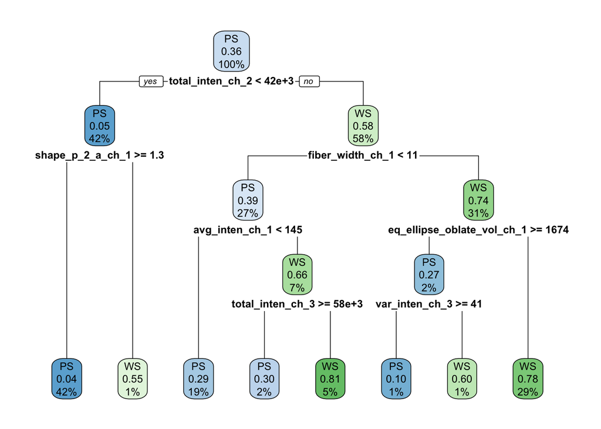

```r
final_tree |>
  extract_fit_engine() |>
  rpart.plot(roundint = F)
```

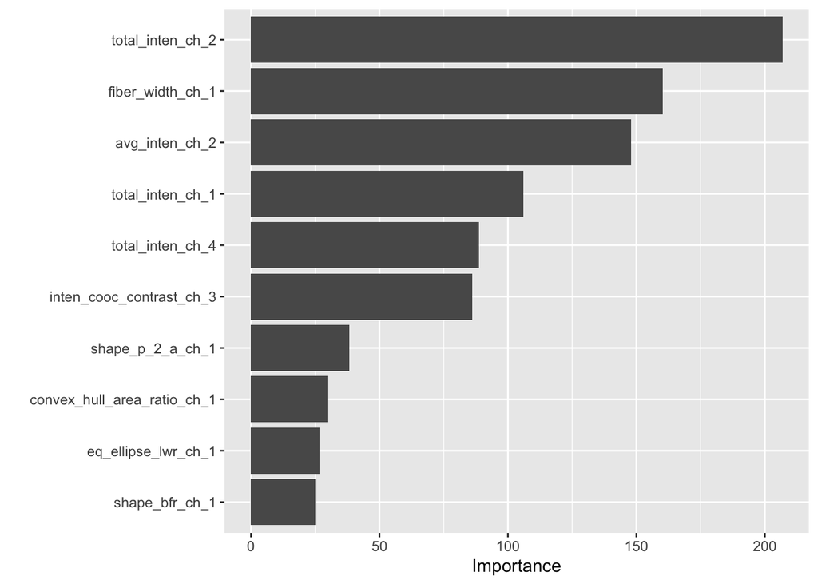

```r
final_tree |>
  extract_fit_parsnip() |>
  vip()
```